# SH_05_EXPLANATION_TEXT

Form, part, and line number reference · Text report

## Overview

**Description**

Form; part and line number explanation

**Table**

`SH-P05-T99-SUPPLEMENTAL-INFO` (one)

**Location code**

`SCHED-H-PART-06`, `SCHED-H-PART-05-SECTION-C`

**Family**

`SCHED-H-PART-06` · siblings: SH_05_FORM_LINE_REFERENCE, SH_05_IDENTIFIER, SH_06_EXPLANATION_TEXT, SH_06_IDENTIFIER, SH_06_RETURN_REFERENCE

**Data type**

text (xsd: ExplanationType)

**Scope**

PC

**Status**

unreviewed

2

xpaths mapped (2 observed)

53,328

filings with a value

2013–2024

tax years observed

3

open flags (1 errors)

## Flags

| Severity | Flag | Xpath | Detail |
| --- | --- | --- | --- |
| ⚠ error | `COLLISION` | IRS990ScheduleH/SupplementalInformationDetail/ExplanationTxt | 26430 filings contain 2+ of its xpaths; most common set: /Return/ReturnData/IRS990ScheduleH/SupplementalInformationDetail/ExplanationTxt ; /Return/ReturnData/IRS990ScheduleH/SupplementalInformationGrp… |
| ▲ warn | `ONE_REPEATS` | IRS990ScheduleH/SupplementalInformationDetail/ExplanationTxt | one-to-one table, repeats in 97.6% of filings (max 296 per filing) |
| ▲ warn | `ONE_REPEATS` | IRS990ScheduleH/SupplementalInformationGrp/ExplanationTxt | one-to-one table, repeats in 95.2% of filings (max 174 per filing) |

## Xpaths

All mapped xpaths (under /Return/ReturnData or /Return/ReturnHeader), oldest first. Charts label each series by its xpath.

| Xpath | Form | First year | Last year | Versions | Filings | Repeats in |
| --- | --- | --- | --- | --- | --- | --- |
| IRS990ScheduleH/SupplementalInformationDetail/ExplanationTxt | Sched H | 2013 | 2024 | 35 | 26,857 | 97.6% |
| IRS990ScheduleH/SupplementalInformationGrp/ExplanationTxt | Sched H | 2013 | 2024 | 35 | 26,471 | 95.2% |

## Coverage

[figure not shown]

**Table view**

Table view: filings by tax year and series

| Tax year | IRS990ScheduleH/SupplementalInformationDetail/ExplanationTxt | IRS990ScheduleH/SupplementalInformationGrp/ExplanationTxt |
| --- | --- | --- |
| 2013 | 2,427 | 2,260 |
| 2014 | 2,408 | 2,372 |
| 2015 | 2,379 | 2,360 |
| 2016 | 2,321 | 2,294 |
| 2017 | 2,405 | 2,379 |
| 2018 | 2,324 | 2,306 |
| 2019 | 2,303 | 2,286 |
| 2020 | 2,345 | 2,327 |
| 2021 | 2,317 | 2,302 |
| 2022 | 2,345 | 2,330 |
| 2023 | 2,305 | 2,286 |
| 2024 | 978 | 969 |

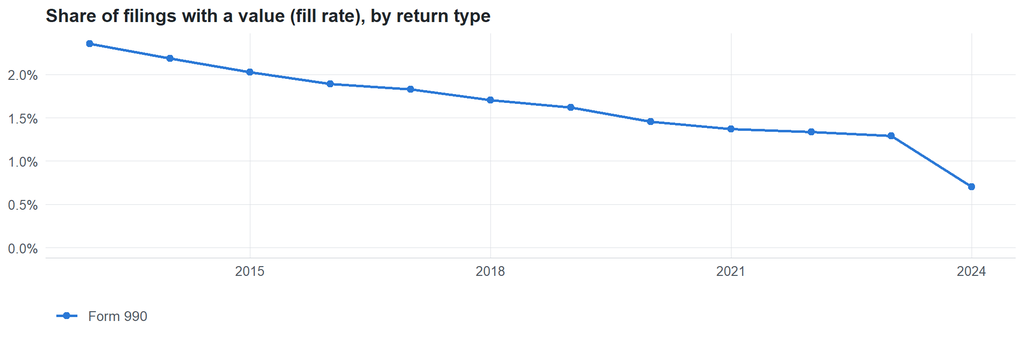

**Table view**

Table view: fill rate

| Tax year | Return type | Filings | All filings | Fill rate |
| --- | --- | --- | --- | --- |
| 2013 | Form 990 | 4,687 | 198,855 | 2.36% |
| 2014 | Form 990 | 4,780 | 218,619 | 2.19% |
| 2015 | Form 990 | 4,739 | 233,519 | 2.03% |
| 2016 | Form 990 | 4,615 | 243,903 | 1.89% |
| 2017 | Form 990 | 4,784 | 261,612 | 1.83% |
| 2018 | Form 990 | 4,630 | 271,442 | 1.71% |
| 2019 | Form 990 | 4,589 | 283,694 | 1.62% |
| 2020 | Form 990 | 4,672 | 320,342 | 1.46% |
| 2021 | Form 990 | 4,619 | 336,480 | 1.37% |
| 2022 | Form 990 | 4,675 | 349,055 | 1.34% |
| 2023 | Form 990 | 4,591 | 354,768 | 1.29% |
| 2024 | Form 990 | 1,947 | 277,298 | 0.70% |

## Repeating groups

Table cardinality in the concordance: **one**. 2 of 2 observed xpaths repeat within a filing.

Repeating element each xpath was observed in (from the raw indexed xpath)

| Xpath | Repeating element | Filings (summed over years) |
| --- | --- | --- |
| IRS990ScheduleH/SupplementalInformationDetail/ExplanationTxt | (none) | 645 |
| IRS990ScheduleH/SupplementalInformationDetail/ExplanationTxt | IRS990ScheduleH/SupplementalInformationDetail | 26212 |
| IRS990ScheduleH/SupplementalInformationGrp/ExplanationTxt | (none) | 1281 |
| IRS990ScheduleH/SupplementalInformationGrp/ExplanationTxt | IRS990ScheduleH/SupplementalInformationGrp | 25190 |

## Values

[output not shown]

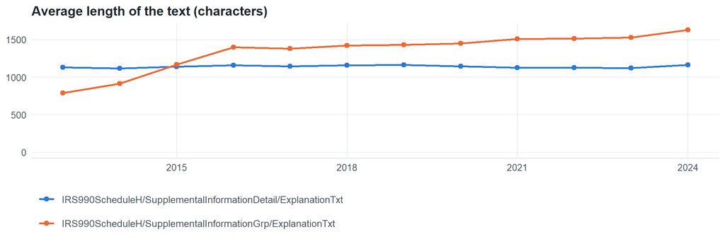

**Table view**

Table view: length and variety by tax year

| Series | Tax year | Filings | Avg length | Max length | Distinct values (approx.) |
| --- | --- | --- | --- | --- | --- |
| IRS990ScheduleH/SupplementalInformationDetail/ExplanationTxt | 2013 | 2,427 | 1,131 | 9,000 | 18,161 |
| IRS990ScheduleH/SupplementalInformationDetail/ExplanationTxt | 2014 | 2,408 | 1,115 | 9,000 | 14,797 |
| IRS990ScheduleH/SupplementalInformationDetail/ExplanationTxt | 2015 | 2,379 | 1,139 | 9,000 | 19,002 |
| IRS990ScheduleH/SupplementalInformationDetail/ExplanationTxt | 2016 | 2,321 | 1,158 | 9,000 | 13,209 |
| IRS990ScheduleH/SupplementalInformationDetail/ExplanationTxt | 2017 | 2,405 | 1,142 | 9,000 | 21,525 |
| IRS990ScheduleH/SupplementalInformationDetail/ExplanationTxt | 2018 | 2,324 | 1,155 | 9,000 | 14,446 |
| IRS990ScheduleH/SupplementalInformationDetail/ExplanationTxt | 2019 | 2,303 | 1,161 | 9,000 | 8,974 |
| IRS990ScheduleH/SupplementalInformationDetail/ExplanationTxt | 2020 | 2,345 | 1,145 | 9,000 | 9,475 |
| IRS990ScheduleH/SupplementalInformationDetail/ExplanationTxt | 2021 | 2,317 | 1,127 | 9,000 | 24,332 |
| IRS990ScheduleH/SupplementalInformationDetail/ExplanationTxt | 2022 | 2,345 | 1,123 | 9,000 | 25,932 |
| IRS990ScheduleH/SupplementalInformationDetail/ExplanationTxt | 2023 | 2,305 | 1,118 | 9,000 | 13,977 |
| IRS990ScheduleH/SupplementalInformationDetail/ExplanationTxt | 2024 | 978 | 1,162 | 9,000 | 7,856 |
| IRS990ScheduleH/SupplementalInformationGrp/ExplanationTxt | 2013 | 2,260 | 787 | 9,000 | 5,449 |
| IRS990ScheduleH/SupplementalInformationGrp/ExplanationTxt | 2014 | 2,372 | 913 | 9,000 | 7,065 |
| IRS990ScheduleH/SupplementalInformationGrp/ExplanationTxt | 2015 | 2,360 | 1,166 | 9,000 | 6,875 |
| IRS990ScheduleH/SupplementalInformationGrp/ExplanationTxt | 2016 | 2,294 | 1,395 | 9,000 | 7,983 |
| IRS990ScheduleH/SupplementalInformationGrp/ExplanationTxt | 2017 | 2,379 | 1,377 | 9,000 | 10,630 |
| IRS990ScheduleH/SupplementalInformationGrp/ExplanationTxt | 2018 | 2,306 | 1,420 | 9,000 | 8,355 |
| IRS990ScheduleH/SupplementalInformationGrp/ExplanationTxt | 2019 | 2,286 | 1,430 | 9,006 | 5,861 |
| IRS990ScheduleH/SupplementalInformationGrp/ExplanationTxt | 2020 | 2,327 | 1,450 | 9,006 | 4,841 |
| IRS990ScheduleH/SupplementalInformationGrp/ExplanationTxt | 2021 | 2,302 | 1,506 | 9,000 | 13,753 |
| IRS990ScheduleH/SupplementalInformationGrp/ExplanationTxt | 2022 | 2,330 | 1,512 | 9,000 | 16,401 |
| IRS990ScheduleH/SupplementalInformationGrp/ExplanationTxt | 2023 | 2,286 | 1,528 | 9,000 | 9,719 |
| IRS990ScheduleH/SupplementalInformationGrp/ExplanationTxt | 2024 | 969 | 1,629 | 9,000 | 3,455 |

Most common values by xpath (all years; long values truncated)

| Series | Value | Filings | Share |
| --- | --- | --- | --- |
| IRS990ScheduleH/SupplementalInformationDetail/ExplanationTxt | THE BAD DEBT EXPENSE INCLUDED ON FORM 990, PART IX, LINE 25, COLUMN (A), BUT SUBTRACTED FOR PURPOSES | 2,277 | 8.5% |
| IRS990ScheduleH/SupplementalInformationDetail/ExplanationTxt | N/A | 1,442 | 5.4% |
| IRS990ScheduleH/SupplementalInformationDetail/ExplanationTxt | CA | 734 | 2.7% |
| IRS990ScheduleH/SupplementalInformationDetail/ExplanationTxt | IL | 703 | 2.6% |
| IRS990ScheduleH/SupplementalInformationDetail/ExplanationTxt | WI | 660 | 2.5% |
| IRS990ScheduleH/SupplementalInformationDetail/ExplanationTxt | NY | 616 | 2.3% |
| IRS990ScheduleH/SupplementalInformationDetail/ExplanationTxt | The Bad Debt expense included on Form 990, Part IX, Line 25, Column (A), but subtracted for purposes | 449 | 1.7% |
| IRS990ScheduleH/SupplementalInformationDetail/ExplanationTxt | BASED ON THE ORGANIZATION’S ADMINISTRATION OF ITS FINANCIAL ASSISTANCE PROGRAM, NO ESTIMATE FOR BAD | 236 | 0.9% |
| IRS990ScheduleH/SupplementalInformationDetail/ExplanationTxt | A COST TO CHARGE RATIO IS APPLIED TO THE ORGANIZATION’S MEDICARE GROSS CHARGES TO CALCULATE MEDICARE | 235 | 0.9% |
| IRS990ScheduleH/SupplementalInformationDetail/ExplanationTxt | THE ORGANIZATION IS PART OF THE ASCENSION HEALTH ALLIANCE’S CONSOLIDATED AUDIT IN WHICH THE FOOTNOTE | 226 | 0.8% |
| IRS990ScheduleH/SupplementalInformationDetail/ExplanationTxt | TX | 167 | 0.6% |
| IRS990ScheduleH/SupplementalInformationDetail/ExplanationTxt | THE ORGANIZATION ADMINISTERS ITS FINANCIAL ASSISTANCE POLICY IN ACCORDANCE WITH THE TERMS OF THE POL | 157 | 0.6% |
| IRS990ScheduleH/SupplementalInformationDetail/ExplanationTxt | THE ORGANIZATION IS PART OFASCENSION HEALTH ALLIANCE’S CONSOLIDATED AUDIT IN WHICH THE FOOTNOTE THAT | 156 | 0.6% |
| IRS990ScheduleH/SupplementalInformationDetail/ExplanationTxt | IN ADDITION TO FPG, THE ORGANIZATION USES MEDICAL INDIGENCY, ASSET TEST, INSURANCE STATUS AND RESIDE | 154 | 0.6% |
| IRS990ScheduleH/SupplementalInformationDetail/ExplanationTxt | THE COST OF PROVIDING CHARITY CARE, MEANS-TESTED GOVERNMENT PROGRAMS, AND OTHER COMMUNITY BENEFIT PR | 153 | 0.6% |
| IRS990ScheduleH/SupplementalInformationDetail/ExplanationTxt | THE BEST AVAILABLE DATA WAS USED TO CALCULATE THE COST AMOUNTS REPORTED IN ITEM 7. FOR CERTAIN CATEG | 125 | 0.5% |
| IRS990ScheduleH/SupplementalInformationDetail/ExplanationTxt | The cost of providing charity care, means-tested government programs, and other community benefit pr | 119 | 0.4% |
| IRS990ScheduleH/SupplementalInformationDetail/ExplanationTxt | NOTIFICATION ABOUT THE AVAILABILITY OF FINANCIAL ASSISTANCE FROM CHI HOSPITAL ORGANIZATIONS SHALL BE | 109 | 0.4% |
| IRS990ScheduleH/SupplementalInformationDetail/ExplanationTxt | The cost of providing charity care, means tested government programs, and community benefit programs | 97 | 0.4% |
| IRS990ScheduleH/SupplementalInformationDetail/ExplanationTxt | During tax year 2017, the organization learned via verbal comments of IRS agents at public events th | 92 | 0.3% |
| IRS990ScheduleH/SupplementalInformationDetail/ExplanationTxt | The organization has a written debt collection policy that also includes a provision on the collecti | 81 | 0.3% |
| IRS990ScheduleH/SupplementalInformationDetail/ExplanationTxt | After satisfaction of amounts due from insurance and reasonable efforts to collect from patients who | 77 | 0.3% |
| IRS990ScheduleH/SupplementalInformationDetail/ExplanationTxt | After satisfaction of amounts due from insurance and reasonable efforts to collect from the patient | 76 | 0.3% |
| IRS990ScheduleH/SupplementalInformationDetail/ExplanationTxt | The provision for doubtful accounts is based upon management’s assessment of expected net collection | 76 | 0.3% |
| IRS990ScheduleH/SupplementalInformationDetail/ExplanationTxt | The organization is part of the Ascension Health Alliance’s consolidated audit in which the footnote | 70 | 0.3% |
| IRS990ScheduleH/SupplementalInformationDetail/ExplanationTxt | A cost to charge ratio is applied to the organization’s Medicare Expense to determine the Medicare a | 66 | 0.2% |
| IRS990ScheduleH/SupplementalInformationDetail/ExplanationTxt | COMMONSPIRIT HEALTH HOSPITALS PREPARE MEDICARE COST REPORTS IN A MANNER THAT COMPORTS WITH PROVIDER | 62 | 0.2% |
| IRS990ScheduleH/SupplementalInformationDetail/ExplanationTxt | The organization is affiliated with CommonSpirit Health. CommonSpirit Health was created by the alig | 59 | 0.2% |
| IRS990ScheduleH/SupplementalInformationDetail/ExplanationTxt | THE ORGANIZATION IS AFFILIATED WITH COMMONSPIRIT HEALTH. COMMONSPIRIT HEALTH WAS CREATED BY THE ALIG | 56 | 0.2% |
| IRS990ScheduleH/SupplementalInformationDetail/ExplanationTxt | Notification about the availability of Financial Assistance from CHI Hospital Organizations shall be | 54 | 0.2% |

First rows shown.

## Examples

| Tax year | Return | Xpath | Organization | Value | Source |
| --- | --- | --- | --- | --- | --- |
| 2024 | 990 | IRS990ScheduleH/SupplementalInformationDetail/ExplanationTxt | NAVICENT HEALTH BALDWIN INC | THE FINANCIAL ASSISTANCE PROGRAMS ARE DESIGNED TO ENSURE ASSISTANCE IS PROVIDED TO PATIENTS DEMONSTR | [XML](https://gt990datalake-rawdata.s3.amazonaws.com/EfileData/XmlFiles/202543219349301709_public.xml) |
| 2024 | 990 | IRS990ScheduleH/SupplementalInformationGrp/ExplanationTxt | THE CLEVELAND CLINIC FOUNDATION | PART V, SECTION B, LINE 5: DURING 2022, INPUT FROM THE COMMUNITY WAS RECEIVED THROUGH KEY INFORMANT | [XML](https://gt990datalake-rawdata.s3.amazonaws.com/EfileData/XmlFiles/202513189349302136_public.xml) |
| 2023 | 990 | IRS990ScheduleH/SupplementalInformationDetail/ExplanationTxt | Catholic Medical Center | The Bad Debt expense included on Form 990, Part IX, Line 25, Column (A), but subtracted for purposes | [XML](https://gt990datalake-rawdata.s3.amazonaws.com/EfileData/XmlFiles/202522279349303467_public.xml) |
| 2023 | 990 | IRS990ScheduleH/SupplementalInformationGrp/ExplanationTxt | ARH TUG VALLEY HEALTH SERVICES INC | HTTPS://WWW.ARH.ORG/FINANCIAL-ASSISTANCE/ | [XML](https://gt990datalake-rawdata.s3.amazonaws.com/EfileData/XmlFiles/202511349349306946_public.xml) |
| 2022 | 990 | IRS990ScheduleH/SupplementalInformationDetail/ExplanationTxt | RUSSELL HOSPITAL CORPORATION | THE DATA REPORTED IN THIS AREA IS REPORTED AS INSTRUCTED BY CATHOLIC HEALTH ASSOCIATION’S ““““A GUIDE F | [XML](https://gt990datalake-rawdata.s3.amazonaws.com/EfileData/XmlFiles/202333179349300113_public.xml) |
| 2022 | 990 | IRS990ScheduleH/SupplementalInformationGrp/ExplanationTxt | RUSSELL HOSPITAL CORPORATION | THE COMMUNITY HEALTH NEEDS OF RESIDENTS WITHIN RUSSELL MEDICALS PRIMARY SERVICE AREA WERE IDENTIFIED | [XML](https://gt990datalake-rawdata.s3.amazonaws.com/EfileData/XmlFiles/202333179349300113_public.xml) |
| 2021 | 990 | IRS990ScheduleH/SupplementalInformationDetail/ExplanationTxt | TRI-COUNTY MEMORIAL HOSPITAL INC | IN ADDITION TO THE INCOME LEVEL THRESHOLDS, ASSETS MUST BE BELOW 600% OF FPG. AN ADDITIONAL DISCOUNT | [XML](https://gt990datalake-rawdata.s3.amazonaws.com/EfileData/XmlFiles/202243199349308309_public.xml) |
| 2021 | 990 | IRS990ScheduleH/SupplementalInformationGrp/ExplanationTxt | COMMUNITY HOSPITAL OF ANDERSON AND | PART V, SECTION B, LINE 7A:HTTPS://WWW.ECOMMUNITY.COM/COMMUNITY-BENEFIT/ARCHIVED-REPORTSPART V, SECT | [XML](https://gt990datalake-rawdata.s3.amazonaws.com/EfileData/XmlFiles/202203149349305235_public.xml) |
| 2020 | 990 | IRS990ScheduleH/SupplementalInformationDetail/ExplanationTxt | Southeast Volusia Healthcare Corporation | The filing organization was a wholly owned subsidiary of Adventist Health System Sunbelt Healthcare | [XML](https://gt990datalake-rawdata.s3.amazonaws.com/EfileData/XmlFiles/202103199349312315_public.xml) |
| 2020 | 990 | IRS990ScheduleH/SupplementalInformationGrp/ExplanationTxt | Southeast Volusia Healthcare Corporation | Part V, Section B, Line 5: Southeast Volusia Healthcare Corporation, d/b/a AdventHealth New Smyrna B | [XML](https://gt990datalake-rawdata.s3.amazonaws.com/EfileData/XmlFiles/202103199349312315_public.xml) |
| 2019 | 990 | IRS990ScheduleH/SupplementalInformationDetail/ExplanationTxt | SELF REGIONAL HEALTHCARE PARTNERS | THE BAD DEBT EXPENSE INCLUDED ON FORM 990, PART IX, LINE 25, COLUMN (A), BUT SUBTRACTED FOR PURPOSES | [XML](https://gt990datalake-rawdata.s3.amazonaws.com/EfileData/XmlFiles/202102289349302070_public.xml) |
| 2019 | 990 | IRS990ScheduleH/SupplementalInformationGrp/ExplanationTxt | SELF REGIONAL HEALTHCARE PARTNERS | PART V, SECTION B, LINE 5: THE TEAM USED SEVERAL SOURCES OF QUANTITATIVE HEALTH, SOCIAL AND DEMOGRAP | [XML](https://gt990datalake-rawdata.s3.amazonaws.com/EfileData/XmlFiles/202102289349302070_public.xml) |

## Reviewer checklist

- The definition matches the form line and instructions for every xpath’s schema years.
- Every xpath pooled here measures the same thing on the 990 and 990-EZ (close enough for analysis).
- The coverage chart has no unexplained gaps or jumps between tax years.
- Each open flag is fixed, or accepted with a note in validation_log.csv.
- Values answer the question on the form line (not another line’s explanation).
- Boilerplate such as ‘See Schedule O’ or ‘N/A’ is expected here, or should be treated as missing.
- Text that is really a number or a code is flagged for a different data type.

Record the review as a row in `inst/extdata/src/validation_log.csv` (variable_name, reviewer, date, status, note). Evidence built 2026-09-23 17:09:04 MST from the ef2 DuckDB builds (tax years 2009–2024).